# Introduction to plotting with R and ggplot2

Latest version: https://ongardie.github.io/R-ggplot-intro/

Source code: https://github.com/ongardie/R-ggplot-intro/

Created with [R Markdown](http://rmarkdown.rstudio.com/).

Copyright 2014 Diego Ongaro

This work is licensed under the [Creative Commons Attribution 4.0 International License](http://creativecommons.org/licenses/by/4.0/).

# Getting Started

- Run `R` for interactive REPL
- Getting help

  ```r
  ?length
  ?'+'
  ??zip
  ```

- Installing libraries

  ```r
  install.packages('ggplot2')
  ```

- Run scripts using `Rscript` from command line

  ```bash
  Rscript plots.R
  ```

# R Data Types

- primitives
- vectors
- matrices (won’t cover)
- lists
- data frames

# Primitives

Floating point numbers

```r
3/2
```

```
## [1] 1.5
```

Booleans

```r
TRUE
```

```
## [1] TRUE
```

```r
T
```

```
## [1] TRUE
```

```r
FALSE
```

```
## [1] FALSE
```

```r
F
```

```
## [1] FALSE
```

Missing data:

```r
NA
```

```
## [1] NA
```

```r
is.na(NA)
```

```
## [1] TRUE
```

```r
is.na(FALSE)
```

```
## [1] FALSE
```

Strings:

```r
'hello'
```

```
## [1] "hello"
```

```r
"world"
```

```
## [1] "world"
```

```r
sprintf('I have %d apples and %0.02f bananas', 2, pi)
```

```
## [1] "I have 2 apples and 3.14 bananas"
```

# Vectors

Flat, uniform array of primitives

```r
(vector = c(5, 3, 9)) # extra parens to print value
```

```
## [1] 5 3 9
```

```r
length(vector)
```

```
## [1] 3
```

```r
c(5, 3, 9, FALSE, c(7, 2))
```

```
## [1] 5 3 9 0 7 2
```

Sequences:

```r
10:20
```

```
##  [1] 10 11 12 13 14 15 16 17 18 19 20
```

```r
rep(7, 5)
```

```
## [1] 7 7 7 7 7
```

```r
seq(10, 12, .5)
```

```
## [1] 10.0 10.5 11.0 11.5 12.0
```

Nearly all operations vectorized:

```r
vector * 3
```

```
## [1] 15  9 27
```

```r
vector + 6
```

```
## [1] 11  9 15
```

```r
vector == 3
```

```
## [1] FALSE  TRUE FALSE
```

```r
log10(vector)
```

```
## [1] 0.6990 0.4771 0.9542
```

# Lists

- Sometimes a (Python) list, sometimes a map
- Like a PHP array

```r
values = list(1, 'apple', 4, 'me')
values[[2]]
```

```
## [1] "apple"
```

```r
mapping = list(x=3, y=TRUE, values=values)
mapping[['x']]
```

```
## [1] 3
```

```r
mapping$y
```

```
## [1] TRUE
```

```r
mapping$values[[4]]
```

```
## [1] "me"
```

```r
ls(mapping)
```

```
## [1] "values" "x"      "y"
```

# Data Frames

- Like a database table

  ```r
  ab12 = data.frame(x=c('a', 'b'), y=c(1, 2))
  fmt = knitr::kable # renders data frame nicely
  fmt(ab12)
  ```

  | x | y |
  | --- | --- |
  | a | 1 |
  | b | 2 |

  ```r
  ab12$y
  ```

  [1] 1 2

```r
sample.df = function(df, n=5) {
    df[sample(nrow(df), n),]
}
somecars = sample.df(mtcars)
fmt(somecars)
```

|  | mpg | cyl | disp | hp | drat | wt | qsec | vs | am | gear | carb |
| --- | --- | --- | --- | --- | --- | --- | --- | --- | --- | --- | --- |
| Ford Pantera L | 15.8 | 8 | 351.0 | 264 | 4.22 | 3.170 | 14.50 | 0 | 1 | 5 | 4 |
| Pontiac Firebird | 19.2 | 8 | 400.0 | 175 | 3.08 | 3.845 | 17.05 | 0 | 0 | 3 | 2 |
| Merc 280 | 19.2 | 6 | 167.6 | 123 | 3.92 | 3.440 | 18.30 | 1 | 0 | 4 | 4 |
| Merc 280C | 17.8 | 6 | 167.6 | 123 | 3.92 | 3.440 | 18.90 | 1 | 0 | 4 | 4 |
| Merc 450SLC | 15.2 | 8 | 275.8 | 180 | 3.07 | 3.780 | 18.00 | 0 | 0 | 3 | 3 |

- Projection - vector of column names after the comma

  ```r
  fmt(somecars[, c('mpg', 'hp', 'gear')]) # projection
  ```

  |  | mpg | hp | gear |
  | --- | --- | --- | --- |
  | Ford Pantera L | 15.8 | 264 | 5 |
  | Pontiac Firebird | 19.2 | 175 | 3 |
  | Merc 280 | 19.2 | 123 | 4 |
  | Merc 280C | 17.8 | 123 | 4 |
  | Merc 450SLC | 15.2 | 180 | 3 |

- Selection - vector of booleans before the comma

  ```r
  (medianmpg = median(somecars$mpg))
  ```

  [1] 17.8

  ```r
  fmt(somecars[somecars$mpg > medianmpg, ])
  ```

  |  | mpg | cyl | disp | hp | drat | wt | qsec | vs | am | gear | carb |
  | --- | --- | --- | --- | --- | --- | --- | --- | --- | --- | --- | --- |
  | Pontiac Firebird | 19.2 | 8 | 400.0 | 175 | 3.08 | 3.845 | 17.05 | 0 | 0 | 3 | 2 |
  | Merc 280 | 19.2 | 6 | 167.6 | 123 | 3.92 | 3.440 | 18.30 | 1 | 0 | 4 | 4 |

- Combined

  ```r
  fmt(somecars[somecars$mpg > medianmpg, c('hp', 'gear')])
  ```

  |  | hp | gear |
  | --- | --- | --- |
  | Pontiac Firebird | 175 | 3 |
  | Merc 280 | 123 | 4 |

# Our First Scatter Plot

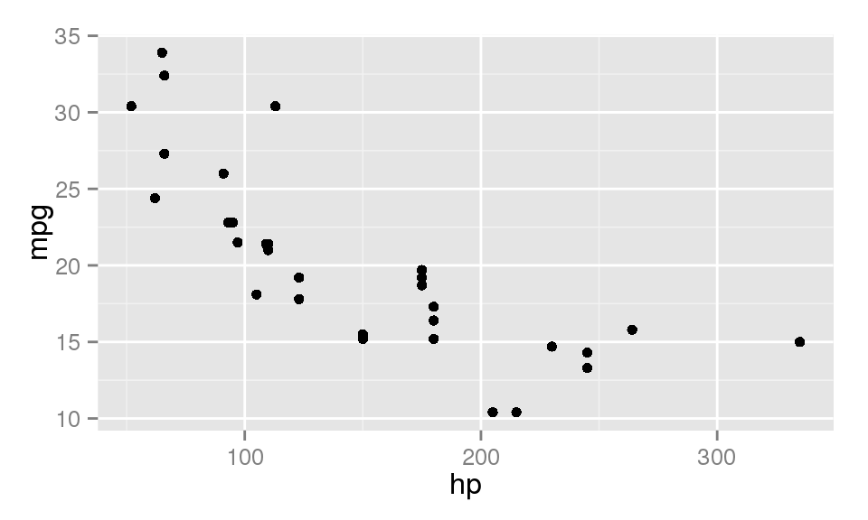

```r
library('ggplot2')
(g = ggplot(mtcars) +
     geom_point(aes(x=hp, y=mpg)))
```

Better zero-base those axes!

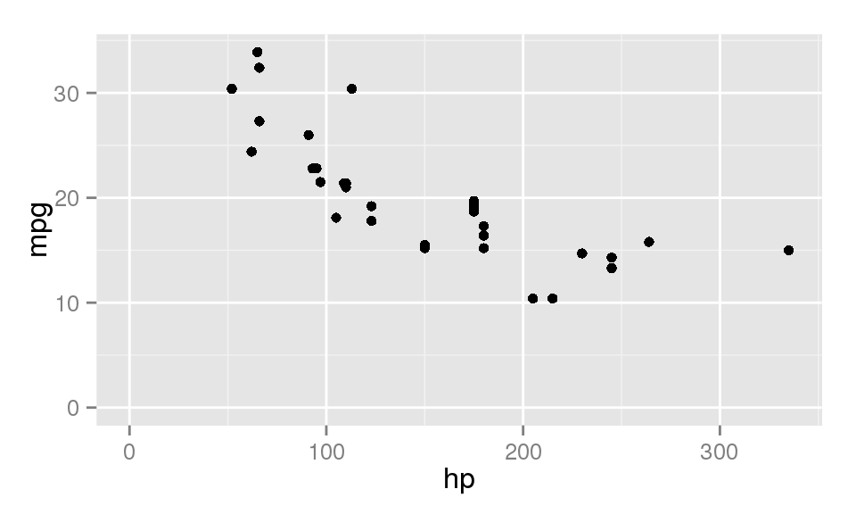

```r
# This makes sure (0,0) is shown in the graph. Alternatively, use
# coord_cartesian() to control the axes' upper and lower bounds.
(g = g + expand_limits(x = 0, y = 0))
```

(BTW, don’t use `qplot`; always spell it out with `ggplot`.)

# A Grouped Bar Graph

Steal allocator dataset from Steve Rumble:

```r
alloc = read.table('allocators.data', header=TRUE)
fmt(alloc)
```

| Allocator | W1 | W2 | W3 | W4 | W5 | W6 | W7 | W8 |
| --- | --- | --- | --- | --- | --- | --- | --- | --- |
| Boehm GC 7.2d | 14.85 | 27.24 | 27.56 | 19.92 | 18.73 | 25.74 | 18.71 | 26.38 |
| glibc 2.12 malloc | 11.20 | 13.73 | 11.76 | 12.23 | 11.75 | 16.38 | 11.17 | 20.16 |
| Hoard 3.9 | 12.83 | 32.61 | 32.61 | 15.38 | 15.38 | 28.63 | 23.79 | 0.00 |
| Java 1.7.0 OpenJDK | 20.43 | 20.42 | 20.43 | 19.67 | 19.67 | 19.83 | 18.81 | 20.81 |
| jemalloc 3.3.0 | 11.44 | 23.00 | 23.00 | 16.87 | 16.80 | 21.99 | 17.13 | 22.66 |
| memcached 1.4.13 | 10.40 | 20.91 | 20.91 | 16.89 | 16.89 | 22.69 | 16.59 | 22.76 |
| tcmalloc 2.0 | 11.29 | 21.81 | 21.81 | 15.90 | 15.84 | 20.97 | 15.25 | 21.64 |

Pretty easy to plot first workload:

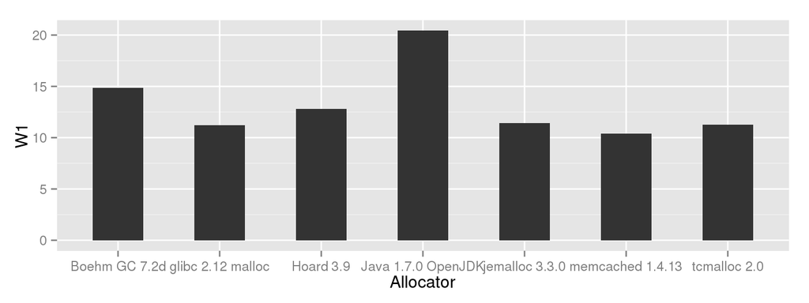

```r
# geom_bar defaults to using frequency for y value; stat='identity' tells it to
# use the y value specified.
(g = ggplot(alloc) +
    geom_bar(aes(x=Allocator, y=W1),
             stat='identity',
             width=.5))
```

To plot all the workloads, we first need to blow up the data frame from the current wide format to a long format:

```r
library(reshape2)
alloclong = melt(alloc,
    id.vars = c('Allocator'),
    variable.name='workload',
    value.name='GB')
fmt(sample.df(alloclong))
```

|  | Allocator | workload | GB |
| --- | --- | --- | --- |
| 46 | Java 1.7.0 OpenJDK | W7 | 18.81 |
| 5 | jemalloc 3.3.0 | W1 | 11.44 |
| 35 | tcmalloc 2.0 | W5 | 15.84 |
| 24 | Hoard 3.9 | W4 | 15.38 |
| 10 | Hoard 3.9 | W2 | 32.61 |

Now we can plot this long-format data:

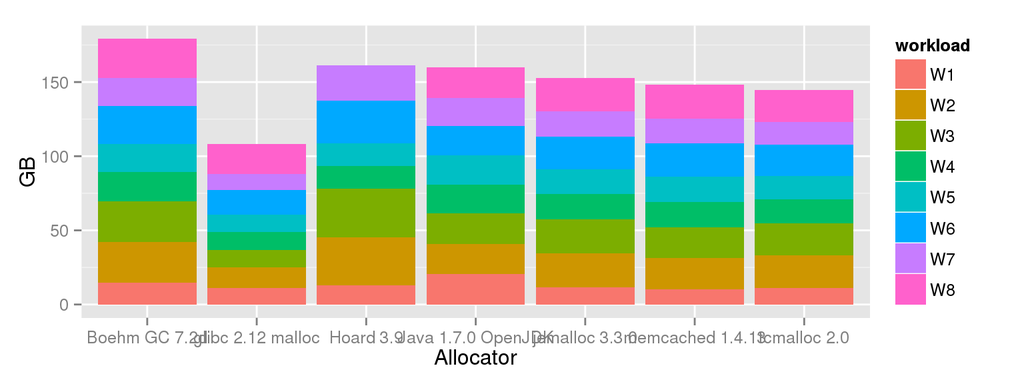

```r
(g = ggplot(alloclong) +
        geom_bar(aes(x=Allocator, y=GB, fill=workload),
                 stat='identity'))
```

Oops, that was stacked. Interesting, but not what we wanted. Need to change position from default `stack` to `dodge`.

Also, too much rainbow? Built-in [ColorBrewer](http://colorbrewer2.org/).

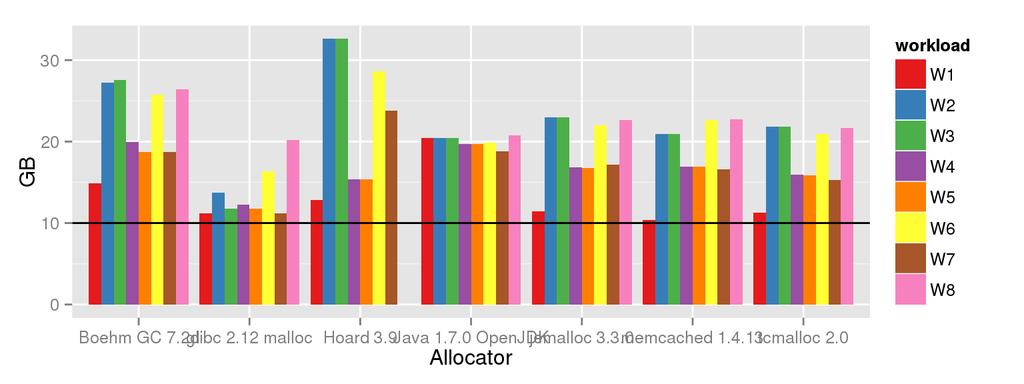

```r
(g = ggplot(alloclong) +
        geom_bar(aes(x=Allocator, y=GB, fill=workload),
                 stat='identity',
                 position='dodge') +
        scale_fill_brewer(palette='Set1') +
        geom_abline(intercept=10, slope=0))
```

# CDFs

Got some raw data about RAMCloud latencies from Collin.

```r
f = bzfile('rpcServiceTime.txt.bz2', 'r+')
readLines(f, n=5)
```

```
## [1] "1.4690,10.5690,1.4486,1.2706,1.3211,1.2515,1.0736,1.0661,1.1356,1.1786"
## [2] "1.0081,1.0865,1.0552,0.9785,1.0661,1.0531,1.0136,1.3201,1.1281,1.0436"
## [3] "1.0115,1.0811,0.9955,1.0875,0.9665,1.0190,1.0575,0.9900,1.0715,1.0061"
## [4] "1.0886,0.9975,0.9924,1.1786,1.0436,1.0010,1.0136,1.0985,0.9730,1.0156"
## [5] "0.9750,0.9645,1.0160,1.1827,1.0395,0.9635,0.9761,1.0211,1.0385,1.0095"
```

```r
f = bzfile('rpcServiceTime.txt.bz2', 'r+')
system.time({
    rpcServiceTime = scan(f, sep=',') # slow!
})
```

```
##    user  system elapsed
##   8.512   0.080   8.598
```

```r
head(rpcServiceTime)
```

```
## [1]  1.469 10.569  1.449  1.271  1.321  1.252
```

```r
length(rpcServiceTime)
```

```
## [1] 8000331
```

```r
latency = data.frame(rpcServiceTime=rpcServiceTime)
```

Unfortunately, creating a CDF in the normal way with ggplot takes a while.

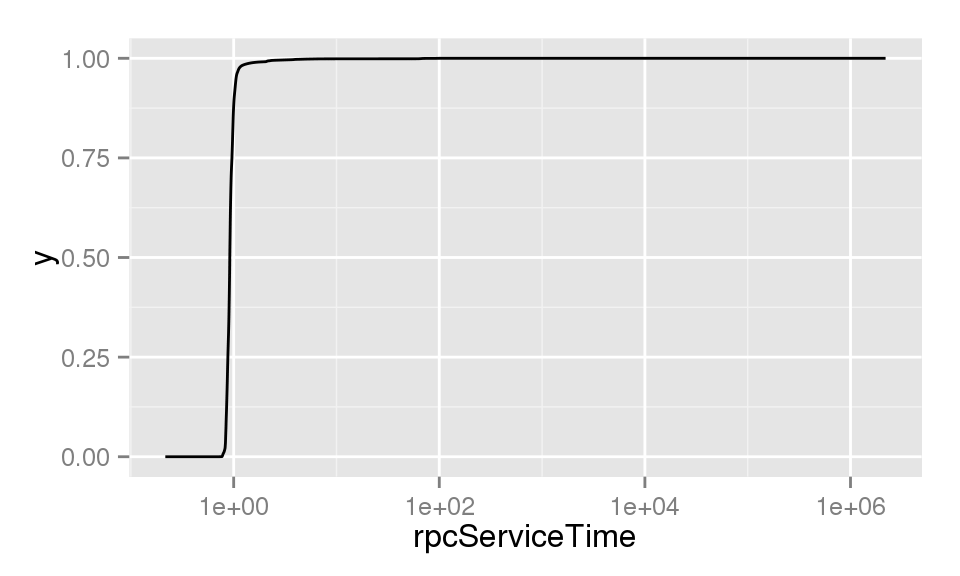

```
##    user  system elapsed
##   9.896   0.380  10.284
```

```r
# slow!
system.time({
    g = ggplot(latency) +
            stat_ecdf(aes(x=rpcServiceTime)) +
            scale_x_log10()
    print(g)
})
```

Let’s pre-process the data first:

```r
system.time({
    times = 10**seq(log10(min(rpcServiceTime)),
                    log10(max(rpcServiceTime)),
                    length.out=1000)
    rpcServiceEcdf = ecdf(rpcServiceTime)
    percentiles = rpcServiceEcdf(times)
    latencypercentiles = data.frame(time=times,
                                    percentile=percentiles)
})
```

```
##    user  system elapsed
##   1.540   0.000   1.542
```

```r
fmt(sample.df(latencypercentiles))
```

|  | time | percentile |
| --- | --- | --- |
| 18 | 8.337e-01 | 0.0417 |
| 181 | 8.063e+00 | 0.9986 |
| 888 | 1.517e+05 | 1.0000 |
| 214 | 1.276e+01 | 0.9987 |
| 273 | 2.902e+01 | 0.9988 |

In practice if you have millions of data points, you might want your benchmark to output its data summarized like this.

Now plotting is fast.

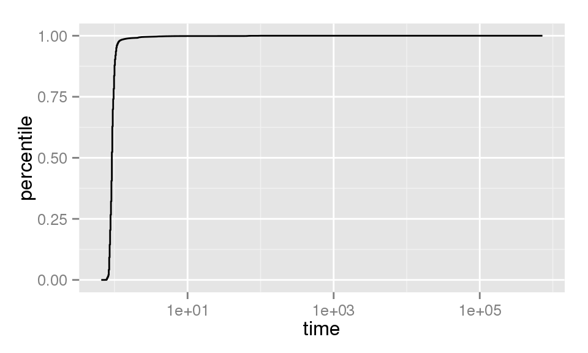

```
##    user  system elapsed
##   0.104   0.000   0.106
```

```r
system.time({
    g = ggplot(latencypercentiles) +
            # no need for stat_ecdf now
            geom_step(aes(x=time, y=percentile)) +
            scale_x_log10()
    print(g)
})
```

If you look very closely, you can see the minor ticks are screwed up. They seem to be buggy with log scales. You can turn them off as follows, or see the next graph for a manual work-around:

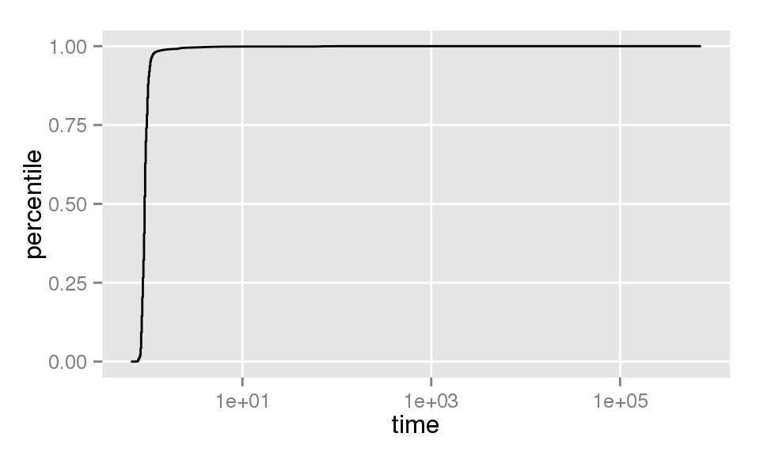

```r
(g = g + theme(panel.grid.minor = element_blank()))
```

Let’s take a closer look at that tail behavior with a John-CDF aka ousterplot.

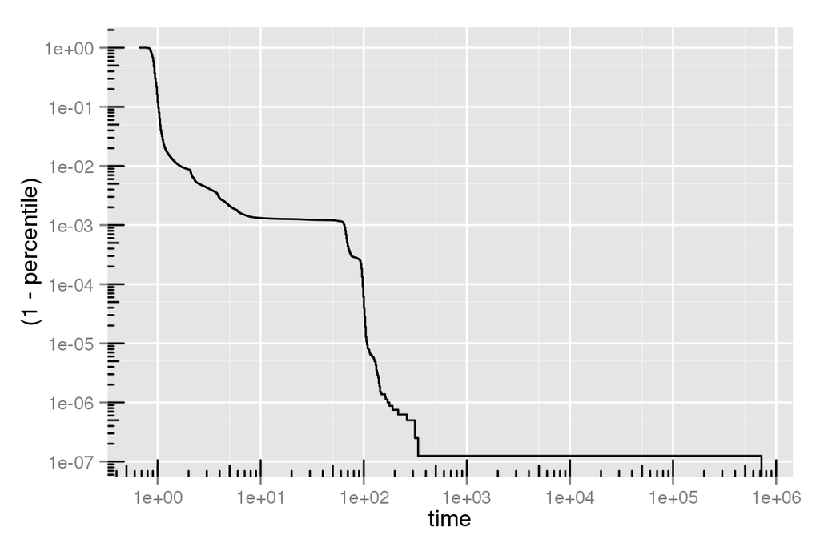

```r
(g = ggplot(latencypercentiles) +
        geom_step(aes(x=time, y=(1 - percentile))) +
        scale_x_log10(breaks=10**(0:6),
                      # have to pass minor_breaks through log10()
                      minor_breaks=log10(5 * 10**(0:6))) +
        scale_y_log10(breaks=10**-(0:7),
                      minor_breaks=log10(5 * 10**-(0:7))) +
        annotation_logticks())
```

# Error Bars

Here’s a dataset from a LogCabin benchmark:

```r
logcabin = read.csv('logcabin.csv')
logcabin$iops = logcabin$writes / (logcabin$timems / 1000)
fmt(sample.df(logcabin))
```

|  | servers | objsize | threads | writes | timems | mbps | iops |
| --- | --- | --- | --- | --- | --- | --- | --- |
| 74 | 1 | 1024 | 1 | 16178 | 10031 | 1.651 | 1613 |
| 28 | 1 | 1024 | 10 | 83753 | 10017 | 8.562 | 8361 |
| 12 | 4 | 1024 | 10 | 47689 | 10023 | 4.872 | 4758 |
| 55 | 3 | 1024 | 1 | 10732 | 10030 | 1.096 | 1070 |
| 73 | 1 | 1024 | 10 | 83530 | 10017 | 8.539 | 8338 |

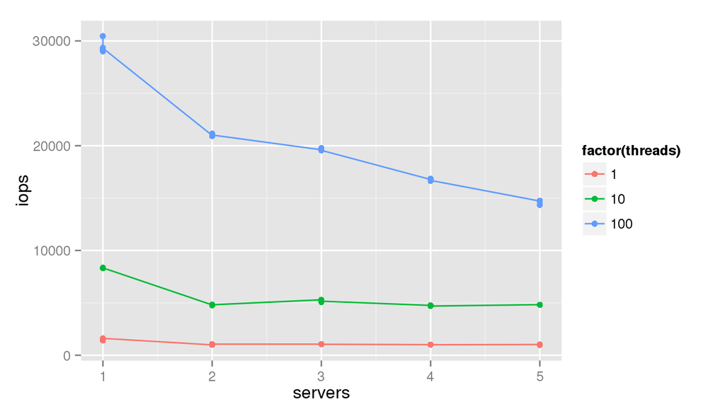

```r
(g = ggplot(logcabin[logcabin$objsize == 2**10, ],
            aes(x=servers,
                y=iops,
                color=factor(threads))) +
     geom_line() +
     geom_point(size=2))
```

That’s close, but there’s multiple runs for each configuration. We really want the lines going through the mean and the error bars showing min/max.

First option: aggressive use of stat_summary.

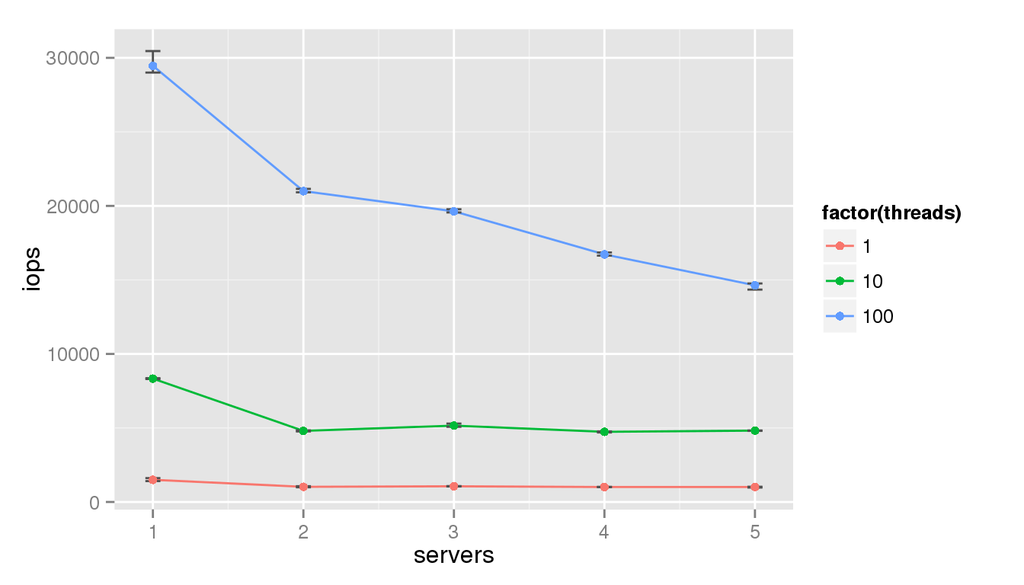

```r
(g = ggplot(logcabin[logcabin$objsize == 2**10, ],
            aes(x=servers,
                y=iops,
                color=factor(threads))) +
     stat_summary(fun.y=mean,
                  geom='line') +
     stat_summary(fun.ymin=min, fun.ymax=max,
                  aes(ymin=..ymin..,
                      ymax=..ymax..,
                      group=factor(threads)),
                  geom='errorbar',
                  color='#505050',
                  width=0.1) +
     stat_summary(fun.y=mean,
                  geom='point',
                  size=2))
```

Alternatively, pre-summarize the data.

```r
library('plyr')
logcabinsum = ddply(logcabin,
        ~ servers + objsize + threads,
        summarize,
        mean_iops=mean(iops),
        min_iops=min(iops),
        max_iops=max(iops))
fmt(sample.df(logcabinsum))
```

|  | servers | objsize | threads | mean_iops | min_iops | max_iops |
| --- | --- | --- | --- | --- | --- | --- |
| 15 | 5 | 1024 | 100 | 14636 | 14345.8 | 14760 |
| 2 | 1 | 1024 | 10 | 8332 | 8306.7 | 8361 |
| 1 | 1 | 1024 | 1 | 1498 | 1412.3 | 1613 |
| 4 | 2 | 1024 | 1 | 1026 | 992.5 | 1065 |
| 7 | 3 | 1024 | 1 | 1063 | 1049.0 | 1074 |

Now we can plot it more easily:

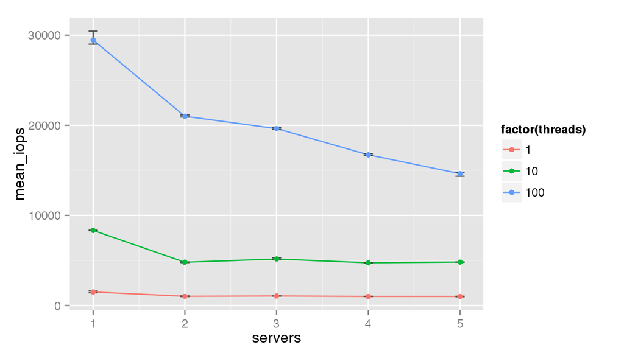

```r
(g = ggplot(logcabinsum[logcabinsum$objsize == 2**10, ],
            aes(x=servers,
                y=mean_iops,
                color=factor(threads))) +
     geom_line() +
     geom_errorbar(aes(ymin = min_iops, ymax = max_iops),
                   color='#505050',
                   width=0.1) +
     geom_point(size=2))
```

# Plotting Mathematical Functions

Use `stat_function` to super-impose a single function.

Here’s a more complex example that plots a bunch of functions. In a Raft cluster, let:

- $s$ be number of available servers,
- $n$ be the full cluster size (so $f=n-s$ servers have failed), and
- $l$ be fixed one-way network latency divided by the election timeout range.

The probability of a split vote is determined by:

$\sum\limits_{k=s - \lfloor n/2 \rfloor}^s \dbinom{s}{k} l^k (1-l)^{s-k}$

Goal: plot split vote rate for various clusters

Rewrite function in R:

```r
summation = function(lower, upper, fun) {
  s = 0
  for (i in lower:upper) {
    s = s + fun(i)
  }
  s
}
splitrate = function(s, n, l) {
  summation(s - floor(n / 2), s, function(k) {
    choose(s, k) * l**k * (1 - l)**(s - k)
  })
}
```

Create data frame for interesting range of inputs:

```r
splitrates = data.frame()
for (n in c(3, 5, 7, 9)) {
  for (s in (floor(n / 2) + 1):n) {
    for (l in seq(0, 1, length.out=200)) {
      rbind(splitrates, data.frame(
        s=s,
        n=n,
        f=n-s,
        l=l,
        p=splitrate(s, n, l)
        ))->splitrates
    }
  }
}
splitrates$s <- factor(splitrates$s)
splitrates$n <- factor(splitrates$n)
splitrates$f <- factor(splitrates$f)
fmt(sample.df(splitrates))
```

|  | s | n | f | l | p |
| --- | --- | --- | --- | --- | --- |
| 2410 | 8 | 9 | 1 | 0.0452 | 0.0003 |
| 774 | 4 | 5 | 1 | 0.8693 | 0.9920 |
| 2462 | 8 | 9 | 1 | 0.3065 | 0.2061 |
| 800 | 4 | 5 | 1 | 1.0000 | 1.0000 |
| 537 | 3 | 5 | 2 | 0.6834 | 0.9683 |

Plot as usual:

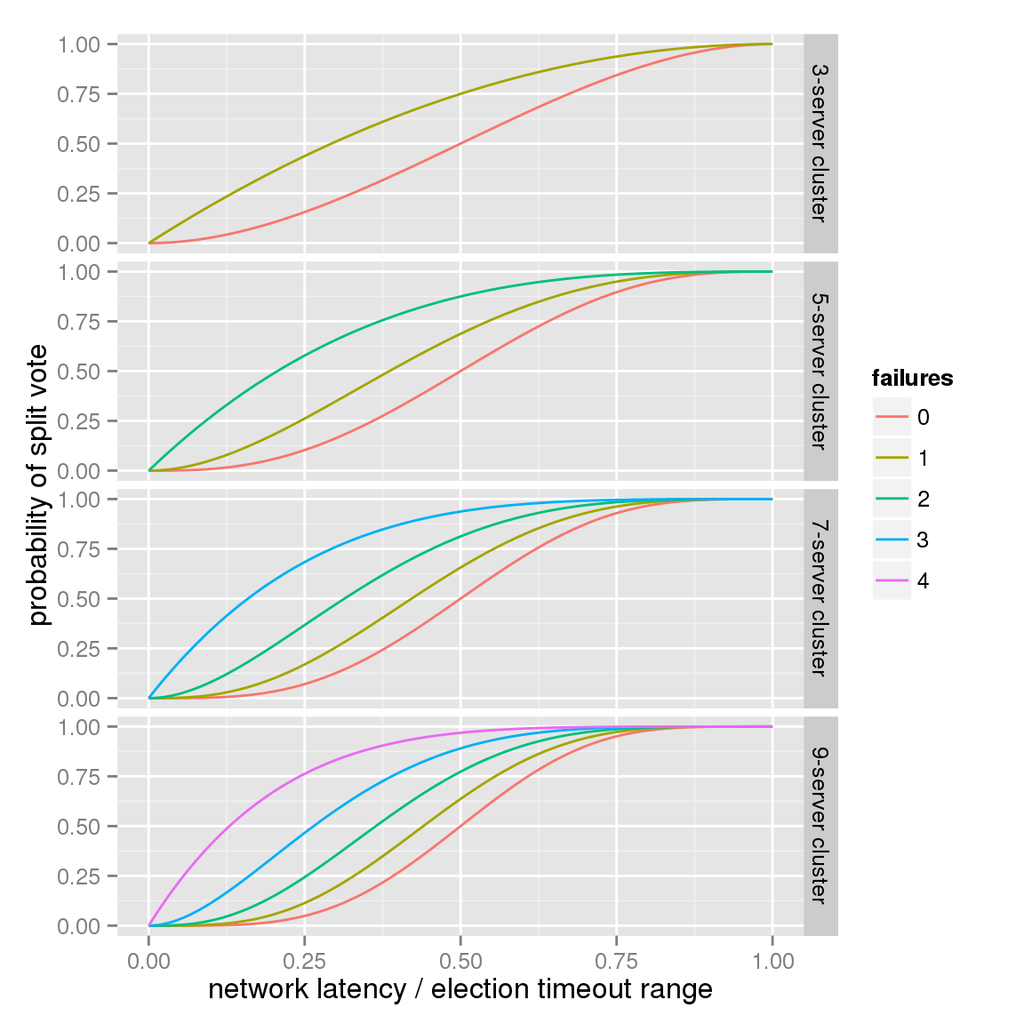

```r
ggplot(splitrates) +
    geom_line(aes(x=l, y=p, color=f)) +
    scale_color_hue('failures', limits=0:4) +
    xlab('network latency / election timeout range') +
    ylab('probability of split vote') +
    facet_grid(n~.,
               labeller=function(var, val) {
                       sprintf('%s-server cluster', val)
                     })
```

# The Grammar of Graphics

**plot:** *coord* *scale+* *facet?* *layer+*

**layer:** *data* *mapping* *stat* *geom* *position?*

**coord:** coordinate system, typically a cartesian grid

**scale:** discrete and continuous axes, colors, shapes, sizes

**facet:** draws related graphs next to each other with different subsets of data

**data and mapping:** define input data (mapping is the `aes()` thing)

**stat:** transforms input data (CDF, summary, binning)

**geom:** draws something (lines, points, bars)

**position:** adjust placement for values with same x coordinate/category (stack, dodge, jitter)

# Limitations

R:

- Slow
- Quirky
- Awful error messages, no line numbers

ggplot2:

- Data size (<1M rows)
- Single y axis
- Facetting with different axes

# Resources

- http://docs.ggplot2.org/current/
- Google and Stack Overflow
- ggplot book (meh)